[figure not shown]

#### 작성자 - 고우주 / 데이터쿱와(주)

# 파이썬 - pandas 기초 실습

# 1. pands 개요

### 1.1 pandas 개요

- 금융회사에 다니고 있던 Wes Mckinney가 처음에 금융 데이터 분석을 위해 2008년 설계
- Pandas: 계량 경제학 용어인 panel data와 analysis의 합성어
- 구조화된 데이터를 빠르고 쉬우면서 다양한 형식으로 가공할 수 있는 풍부한 자료 구조와 함수를 제공
- Pandas의 기본 구조는 numpy로

### 1.2 pandas 특징

- 빅데이터 분석에 최적화 된 필수 패키지
- 데이터는 시계열(series)이나 표(table)의 형태
- 표 데이터를 다루기 위한 시리즈(series) 클래스 변환
- 데이터프레임(dataframe) 클래스 변환

### 1.3 pandas 설치

- pandas는 기본 패키치로 설치되어 있으나, 만약 별로 설치 한다면,
- 터미널과 cmd에서 설치 시 pip install pandas 실행 또는 Jupyter notebook에서 직접 실행

```python
!pip install numpy
```

```
You are using pip version 19.0.3, however version 19.1.1 is available.
```

### 1.4 pandas 패키지 import

- 데이터프레임을 사용하기 위해 pandas 패키지를 임포트 해야한다.
- Pandas는 pd라는 축약어 사용이 관례이다.

```python
import pandas as pd
import numpy as np
```

# 2. 시리즈 클래스 (series class)

### 2.1 시리즈 정의

- 데이터를 리스트나 1차원 배열 형식으로 series 클래스 생성자에 넣어주면 시리즈 클래스 객체를 만들 수 있다.
- 시리즈 클래스는 NumPy에서 제공하는 1차원 배열과 비슷하지만 각 데이터의 의미를 표시하는 **인덱스(index)**를 붙일 수 있다. 데이터 자체는 **값(value)**라고 한다.

> 시리즈 = 인덱스(index) + 값(value)

```python
# Series 정의하여 생성하기
obj = pd.Series([4, 5, -2, 8])
obj
```

```
0    4
1    5
2   -2
3    8
dtype: int64
```

### 2.2 시리즈 확인

```python
# Series의 값만 확인하기
obj.values
```

```
array([ 4,  5, -2,  8])
```

```python
# series의 인덱스 확인하기
obj.index
```

```
RangeIndex(start=0, stop=4, step=1)
```

```python
# series의 데이터타입 확인하기
obj.dtypes
```

```
dtype('int64')
```

### 2.3 시리즈의 인덱스

- 인덱스의 길이는 데이터의 길이와 같아야 하며, 인덱스의 값은 인덱스 라벨(label)
- 인덱스 라벨은 문자열 뿐 아니라 날짜, 시간, 정수 등도 가능

```python
# 인덱스를 리스트로 별도 지정, 반드시 " " 쌍따옴표 사용
obj1 = pd.Series([4, 5, -2, 8], index=["a", "b", "c", "d"])
obj1
```

```
a    4
b    5
c   -2
d    8
dtype: int64
```

### 2.4 시리즈와 딕셔너리 자료형

- Python의 dictionary 자료형을 Series data로 만들 수 있다.
- dictionary의 key가 Series의 index가 된다

```python
data = {"Kim": 35000, "Park": 67000, "Joon": 12000, "Choi": 4000}
```

```python
obj2 = pd.Series(data)
obj2
```

```
Kim     35000
Park    67000
Joon    12000
Choi     4000
dtype: int64
```

```python
# 시리즈 이름 지정 및 index name 지정
obj2.name = "Salary"
obj2.index.name = "Names"

obj2
```

```
Names
Kim     35000
Park    67000
Joon    12000
Choi     4000
Name: Salary, dtype: int64
```

```python
# index 이름 변경
obj2.index = ["A", "B", "C", "D"]
obj2
```

```
A    35000
B    67000
C    12000
D     4000
Name: Salary, dtype: int64
```

### 2.5 2.4 시리즈 연산

- Numpy 배열처럼 시리즈도 벡터화 연산 가능
- 시리즈의 값에만 적용되며 인덱스 값은 변하지 않는다

```python
obj * 10
```

```
0    40
1    50
2   -20
3    80
dtype: int64
```

```python
# 인덱싱 끼리 연산
obj1 * obj1
```

```
a    16
b    25
c     4
d    64
dtype: int64
```

```python
# values 값끼리 연산
obj1.values + obj.values
```

```
array([ 8, 10, -4, 16])
```

### 2.5 시리즈 인덱싱

- 시리즈는 numpy 배열의 인덱스 방법처럼 사용 외에 인덱스 라벨을 이용한 인덱싱
- 배열 인덱싱은 자료의 순서를 바꾸거나 특정한 자료만 선택 가능
- 라벨 값이 영문 문자열인 경우에는 마치 속성인것처럼 점(.)을 이용하여 접근

```python
a = pd.Series([1024, 2048, 3096, 6192],
              index=["서울", "부산", "인천", "대구"])
a
```

```
서울    1024
부산    2048
인천    3096
대구    6192
dtype: int64
```

```python
a[1], a["부산"]
```

```
(2048, 2048)
```

```python
a[3], a["대구"]
```

```
(6192, 6192)
```

```python
a[[0, 3, 1]]
```

```
서울    1024
대구    6192
부산    2048
dtype: int64
```

```python
a[["서울", "대구", "부산"]]
```

```
서울    1024
대구    6192
부산    2048
dtype: int64
```

```python
# 라벨 값이 영문 문자열인 경우에는 마치 속성인것처럼 점(.)을 이용하여 접근
obj2.A
```

```
35000
```

```python
obj2.C
```

```
12000
```

### 2.6 시리즈 슬라이싱(slicing)

- 배열 인덱싱이나 인덱스 라벨을 이용한 슬라이싱(slicing)도 가능
- 문자열 라벨을 이용한 슬라이싱은 콜론(:) 기호 뒤에 오는 인덱스에 해당하는 값이 결과에 포함

```python
a[1:3]
```

```
부산    2048
인천    3096
dtype: int64
```

```python
a["부산":"대구"]
```

```
부산    2048
인천    3096
대구    6192
dtype: int64
```

### 2.7 시리즈의 데이터 갱신, 추가, 삭제

- 인덱싱을 이용하여 딕셔너리처럼 데이터를 갱신(update)하거나 추가(add)
- 데이터 삭제 시 딕셔너리처럼 del 명령 사용

```python
# 데이터 갱신
a["부산"] = 1234
a
```

```
서울    1024
부산    1234
인천    3096
대구    6192
dtype: int64
```

```python
# 데이터 갱신
a["대구"] = 6543
a
```

```
서울    1024
부산    1234
인천    3096
대구    6543
dtype: int64
```

```python
# del 명령어로 데이터 삭제
del a["서울"]
a
```

```
부산    1234
인천    3096
대구    6543
dtype: int64
```

# 3. 데이터프레임(DataFrame)

### 3.1 데이터프레임(DataFrame) 개요

- 시리즈가 1차원 벡터 데이터에 행 방향 인덱스(row index)이라면,
- 데이터프레임(data-frame) 클래스는 2차원 행렬 데이터에 합친 것으로
- 행 인덱스(row index)와 열 인덱스(column index)를 지정

  > 데이터프레임 = 시리즈{인덱스(index) + 값(value)} + 시리즈 + 시리즈의 연속체

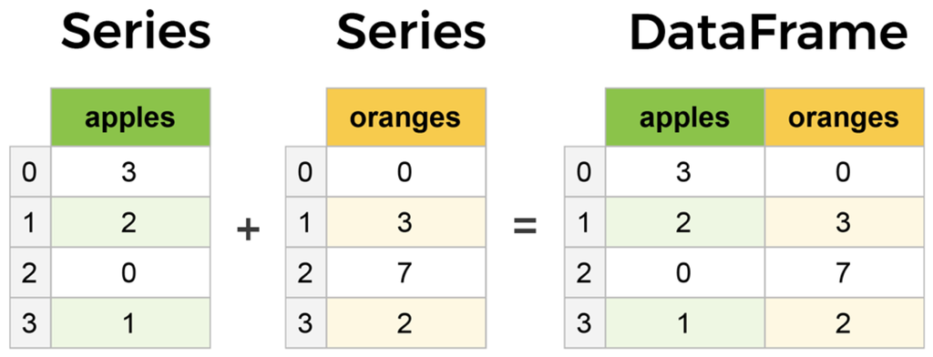

### 3.2 데이터프레임 특성

- 데이터프레임은 공통 인덱스를 가지는 열 시리즈(column series)를 딕셔너리로 묶어놓은 것
- 데이터프레임은 numpy의 모든 2차원 배열 속성이나 메서드를 지원

### 3.3 데이터프레임 생성

1. 우선 하나의 열이 되는 데이터를 리스트나 일차원 배열을 준비
2. 각 열에 대한 이름(label)의 키(key)를 갖는 딕셔너리를 생성
3. pandas의 DataFrame 클래스로 생성
4. 열방향 인덱스는 columns 인수로, 행방향 인덱스는 index 인수로 지정

```python
# Data Frame은 python의 dictionary 또는 numpy의 array로 정의
data = {
'name': ["Choi", "Choi", "Choi", "Kim", "Park"],
'year': [2013, 2014, 2015, 2016, 2017],
'points': [1.5, 1.7, 3.6, 2.4, 2.9]
}
df = pd.DataFrame(data)
df
```

|  | name | year | points |
| --- | --- | --- | --- |
| 0 | Choi | 2013 | 1.5 |
| 1 | Choi | 2014 | 1.7 |
| 2 | Choi | 2015 | 3.6 |
| 3 | Kim | 2016 | 2.4 |
| 4 | Park | 2017 | 2.9 |

```python
# 행 방향의 index
df.index
```

```
RangeIndex(start=0, stop=5, step=1)
```

```python
# 열 방향의 index
df.columns
```

```
Index(['name', 'year', 'points'], dtype='object')
```

```python
df.values
```

```
array([['Choi', 2013, 1.5],
       ['Choi', 2014, 1.7],
       ['Choi', 2015, 3.6],
       ['Kim', 2016, 2.4],
       ['Park', 2017, 2.9]], dtype=object)
```

### 3.4 데이터프레임 열 갱신 추가

- 데이터프레임은 열 시리즈의 딕셔너리로 볼 수 있으므로 열 단위로 데이터를 갱신하거나 추가, 삭제
- data에 포함되어 있지 않은 값은 nan(not a number)으로 나타내는 null과 같은 개념
- 딕셔너리, numpy의 배열, 시리즈의 다양한 방법으로 추가 가능

```python
# DataFrame을 만들면서 columns와 index를 설정
df = pd.DataFrame(data, columns=["year", "name", "points", "penalty"],
                                  index=(["one", "two", "three", "four", "five"]))
df
```

|  | year | name | points | penalty |
| --- | --- | --- | --- | --- |
| one | 2013 | Choi | 1.5 | NaN |
| two | 2014 | Choi | 1.7 | NaN |
| three | 2015 | Choi | 3.6 | NaN |
| four | 2016 | Kim | 2.4 | NaN |
| five | 2017 | Park | 2.9 | NaN |

```python
# 특정 열만 선택
df[["year","points"]]
```

|  | year | points |
| --- | --- | --- |
| one | 2013 | 1.5 |
| two | 2014 | 1.7 |
| three | 2015 | 3.6 |
| four | 2016 | 2.4 |
| five | 2017 | 2.9 |

```python
# 특정 열을 선택하고, 값(0.5)을 대입
df["penalty"] = 0.5
df
```

|  | year | name | points | penalty |
| --- | --- | --- | --- | --- |
| one | 2013 | Choi | 1.5 | 0.5 |
| two | 2014 | Choi | 1.7 | 0.5 |
| three | 2015 | Choi | 3.6 | 0.5 |
| four | 2016 | Kim | 2.4 | 0.5 |
| five | 2017 | Park | 2.9 | 0.5 |

```python
# 또는 python의 리스트로 대입
df['penalty'] = [0.1, 0.2, 0.3, 0.4, 0.5]
df
```

|  | year | name | points | penalty |
| --- | --- | --- | --- | --- |
| one | 2013 | Choi | 1.5 | 0.1 |
| two | 2014 | Choi | 1.7 | 0.2 |
| three | 2015 | Choi | 3.6 | 0.3 |
| four | 2016 | Kim | 2.4 | 0.4 |
| five | 2017 | Park | 2.9 | 0.5 |

```python
import numpy as np

# 또는 numpy의 np.arange로 새로운 열을 추가하기
df['zeros'] = np.arange(5)
df
```

|  | year | name | points | penalty | zeros |
| --- | --- | --- | --- | --- | --- |
| one | 2013 | Choi | 1.5 | 0.1 | 0 |
| two | 2014 | Choi | 1.7 | 0.2 | 1 |
| three | 2015 | Choi | 3.6 | 0.3 | 2 |
| four | 2016 | Kim | 2.4 | 0.4 | 3 |
| five | 2017 | Park | 2.9 | 0.5 | 4 |

```python
# 또는 index인자로 특정행을 지정하여 시리즈(Series)로 추가
val = pd.Series([-1.2, -1.5, -1.7], index=['two','four','five'])

df['debt'] = val
df
```

|  | year | name | points | penalty | zeros | debt |
| --- | --- | --- | --- | --- | --- | --- |
| one | 2013 | Choi | 1.5 | 0.1 | 0 | NaN |
| two | 2014 | Choi | 1.7 | 0.2 | 1 | -1.2 |
| three | 2015 | Choi | 3.6 | 0.3 | 2 | NaN |
| four | 2016 | Kim | 2.4 | 0.4 | 3 | -1.5 |
| five | 2017 | Park | 2.9 | 0.5 | 4 | -1.7 |

```python
# 연산 후 새로운 열을 추가하기
df["net_points"] = df["points"] - df["penalty"]
df
```

|  | year | name | points | penalty | zeros | debt | net_points |
| --- | --- | --- | --- | --- | --- | --- | --- |
| one | 2013 | Choi | 1.5 | 0.1 | 0 | NaN | 1.4 |
| two | 2014 | Choi | 1.7 | 0.2 | 1 | -1.2 | 1.5 |
| three | 2015 | Choi | 3.6 | 0.3 | 2 | NaN | 3.3 |
| four | 2016 | Kim | 2.4 | 0.4 | 3 | -1.5 | 2.0 |
| five | 2017 | Park | 2.9 | 0.5 | 4 | -1.7 | 2.4 |

```python
# 조건 연산으로 열 추가
df["high_points"] = df["net_points"] > 2.0
df
```

|  | year | name | points | penalty | zeros | debt | net_points | high_points |
| --- | --- | --- | --- | --- | --- | --- | --- | --- |
| one | 2013 | Choi | 1.5 | 0.1 | 0 | NaN | 1.4 | False |
| two | 2014 | Choi | 1.7 | 0.2 | 1 | -1.2 | 1.5 | False |
| three | 2015 | Choi | 3.6 | 0.3 | 2 | NaN | 3.3 | True |
| four | 2016 | Kim | 2.4 | 0.4 | 3 | -1.5 | 2.0 | False |
| five | 2017 | Park | 2.9 | 0.5 | 4 | -1.7 | 2.4 | True |

```python
# 열 삭제하기
del df["high_points"]
del df["net_points"]
del df["zeros"]
df
```

|  | year | name | points | penalty | debt |
| --- | --- | --- | --- | --- | --- |
| one | 2013 | Choi | 1.5 | 0.1 | NaN |
| two | 2014 | Choi | 1.7 | 0.2 | -1.2 |
| three | 2015 | Choi | 3.6 | 0.3 | NaN |
| four | 2016 | Kim | 2.4 | 0.4 | -1.5 |
| five | 2017 | Park | 2.9 | 0.5 | -1.7 |

```python
# 컬럼명 확인하기
df.columns
```

```
Index(['year', 'name', 'points', 'penalty', 'debt'], dtype='object')
```

```python
# index와 columns 이름 지정
df.index.name = "Order"
df.columns.name = "Info"
df
```

| Info Order | year | name | points | penalty | debt |
| --- | --- | --- | --- | --- | --- |
| one | 2013 | Choi | 1.5 | 0.1 | NaN |
| two | 2014 | Choi | 1.7 | 0.2 | -1.2 |
| three | 2015 | Choi | 3.6 | 0.3 | NaN |
| four | 2016 | Kim | 2.4 | 0.4 | -1.5 |
| five | 2017 | Park | 2.9 | 0.5 | -1.7 |